# Modeling_ver4_Rmd

## 0. Library

```r
# Base library
library(dplyr)
library(tidyverse)
library(ggplot2)

# Confusion Matrix
library(caret)

# ROC curve
library(ROCR)

# model library
library(rpart)
library(rpart.plot)
library(randomForest)

# plot combine
library(gridExtra)
```

## 1. Data load

```r
breast_cancer <- read.csv("../data/breast_cancer.csv", header=T)

# NULL Data인 X열 제외
breast_cancer <- breast_cancer %>% select(-X)

# 'diagnosis'를 factor 로 변환
breast_cancer$diagnosis <- as.factor(breast_cancer$diagnosis)

# 속성 확인
str(breast_cancer)
```

```
## 'data.frame':    569 obs. of  32 variables:
##  $ id                     : int  842302 842517 84300903 84348301 84358402 843786 844359 84458202 844981 84501001 ...
##  $ diagnosis              : Factor w/ 2 levels "B","M": 2 2 2 2 2 2 2 2 2 2 ...
##  $ radius_mean            : num  18 20.6 19.7 11.4 20.3 ...
##  $ texture_mean           : num  10.4 17.8 21.2 20.4 14.3 ...
##  $ perimeter_mean         : num  122.8 132.9 130 77.6 135.1 ...
##  $ area_mean              : num  1001 1326 1203 386 1297 ...
##  $ smoothness_mean        : num  0.1184 0.0847 0.1096 0.1425 0.1003 ...
##  $ compactness_mean       : num  0.2776 0.0786 0.1599 0.2839 0.1328 ...
##  $ concavity_mean         : num  0.3001 0.0869 0.1974 0.2414 0.198 ...
##  $ concave.points_mean    : num  0.1471 0.0702 0.1279 0.1052 0.1043 ...
##  $ symmetry_mean          : num  0.242 0.181 0.207 0.26 0.181 ...
##  $ fractal_dimension_mean : num  0.0787 0.0567 0.06 0.0974 0.0588 ...
##  $ radius_se              : num  1.095 0.543 0.746 0.496 0.757 ...
##  $ texture_se             : num  0.905 0.734 0.787 1.156 0.781 ...
```

[output cut: 18 more lines]

이 데이터는 유방암 진단에 관련된 정보로 각 변수는 다음과 같은 의미

- id: 환자의 ID
- diagnosis: 진단 결과 (M = 악성, B = 양성)
- radius_mean: 암세포의 평균 반경
- texture_mean: 암세포의 평균 질감
- perimeter_mean: 암세포의 평균 둘레
- area_mean: 암세포의 평균 면적
- smoothness_mean: 암세포의 평균 매끄러움
- compactness_mean: 암세포의 평균 조그만함
- concavity_mean: 암세포의 평균 오목함
- concave.points_mean: 암세포의 평균 오목한 점의 수
- symmetry_mean: 암세포의 평균 대칭성
- fractal_dimension_mean: 암세포의 평균 프랙탈 차원

이외에도 각 특징의 표준 오차(_se)와 최악의 경우(_worst)에 대한 측정치가 포함

#### 데이터 분할

- train.index : 전채 데이터 중 70%를 샘플링한 train index
- breast_cancer.train: train data
- breast_cancer.val : valid data

```r
# seed 고정
set.seed(123)

# 전체 데이터의 행 수
total_rows <- nrow(breast_cancer)

# 고정된 인덱스 생성
fixed_index <- sample(1:total_rows)

# train과 val의 비율을 7:3으로 설정
train_ratio <- 0.7
train_rows <- round(total_rows * train_ratio)

# 고정된 인덱스에서 train 데이터의 인덱스 선택
train.index <- fixed_index[1:train_rows]

# train과 val 데이터로 나누기
breast_cancer.train <- breast_cancer[train.index, ]
breast_cancer.val <- breast_cancer[-train.index, ]

train_count <- nrow(breast_cancer.train)
test_count <- nrow(breast_cancer.val)

cat("train data: ", train_count, "\n", "valid data: ", test_count, "\n")
```

```
## train data:  398
##  valid data:  171
```

여기까지는 약식으로 EDA 부분에서 처리할 내용을 작성한 내용으로 향후 EDA 에서 처리하는 과정으로 대체할 예정

이후부터가 Modeling 본 내용

## 2. Compare ML Model

formula에 *diagnosis ~ 선택한 독립변수들* 의 형태로 저장

EDA를 통해 선택한 독립변수들을 아래 코드에서 확인 및 수정가능

```r
eda_formula <- diagnosis ~

  radius_mean + texture_mean + smoothness_mean +
  compactness_mean + symmetry_mean +fractal_dimension_mean +

  radius_se + texture_se + smoothness_se + compactness_se +
  symmetry_se + fractal_dimension_se
```

*Logistic regresion*, *DecisionTree*, *RandomForest* 3가지 모델에 대해서 성능 비교 진행

```r
# 모델 학습
logit_cancer <- glm(eda_formula, data=breast_cancer.train, family=binomial())
tree_cancer <- rpart(eda_formula, data=breast_cancer.train, method = "class")
rf_cancer <- randomForest(eda_formula, data=breast_cancer.train)
```

### Compare Accuracy

각 모델에 대해서 첫번째로 Accuracy(정확도)를 비교를 진행

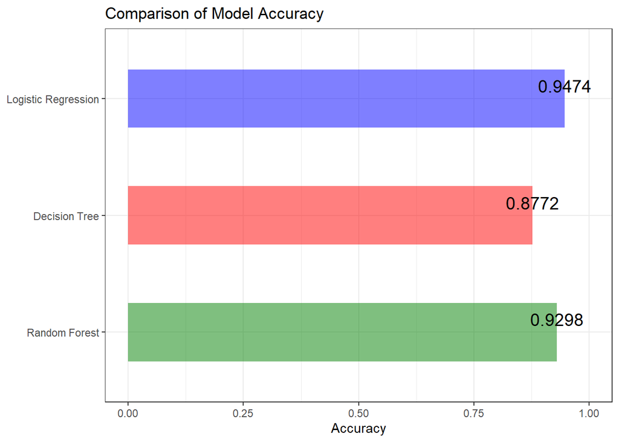

```r
# 각 모델에 대한 예측 생성
logit_pred_acc <- predict(logit_cancer, newdata = breast_cancer.val, type = "response")
tree_pred_acc <- predict(tree_cancer, newdata = breast_cancer.val, type = "class")
rf_pred_acc <- predict(rf_cancer, newdata = breast_cancer.val)

# 예측을 이진 클래스로 변환
logit_pred_class <- ifelse(logit_pred_acc > 0.5, "M", "B")

# 정확도 계산
logit_acc <- mean(logit_pred_class == breast_cancer.val$diagnosis)
tree_acc <- mean(tree_pred_acc == breast_cancer.val$diagnosis)
rf_acc <- mean(rf_pred_acc == breast_cancer.val$diagnosis)

# 정확도를 데이터 프레임으로 변환
acc_df <- data.frame(Model = c("Logistic Regression", "Decision Tree", "Random Forest"),
                     Accuracy = c(logit_acc, tree_acc, rf_acc))

# Model 변수를 팩터로 변환하고 레벨 순서를 지정합니다
acc_df$Model <- factor(acc_df$Model, levels=c("Random Forest", "Decision Tree", "Logistic Regression"))

# 색상을 벡터로 저장합니다
colors <- c("#0000FF80", "#FF000080", "#00800080")

# 바 플롯을 그립니다
ggplot(acc_df, aes(x=Model, y=Accuracy, fill=Model)) +
  geom_bar(stat="identity", width=0.5, fill=colors) +
  ylim(0, 1) +
  geom_text(aes(label=round(Accuracy, 4)), size=5, vjust=-0.5) +
  coord_flip() +
  labs(title="Comparison of Model Accuracy", x="Model", y="Accuracy") +
  theme_bw() +
  theme(legend.position="none", axis.title.y=element_blank())
```

각 모델에 대해서 정확도를 구하고 시각화를 하였을때 Decison Tree < Logistic Regression, Random Forest 순으로 정확도의 성능이 보임  
Logistic Regression 와 Random Forest 정확도가 비슷하게 나오고 있어 정확도로 판단하기 어려움이 있어 AUROC 값을 비교하였음

### Compare ROC & AUROC

다음으로는 Roc 곡선을 시각화 하고 각 모델별 AUROC 비교를 진행

ROC Curve

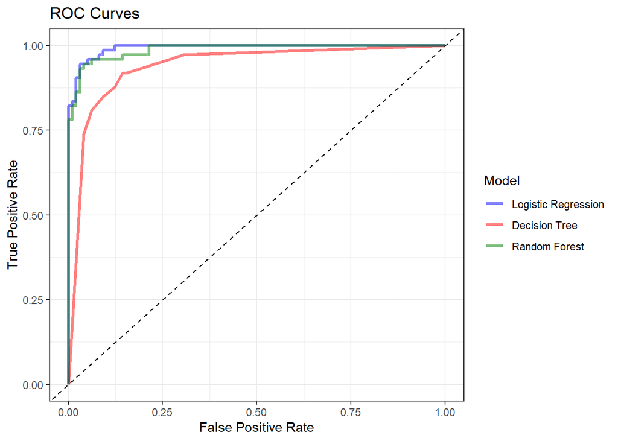

```r
# 각 모델에 대한 예측 생성
logit_pred_roc <- predict(logit_cancer, newdata = breast_cancer.val, type = "response")
tree_pred_roc <- predict(tree_cancer, newdata = breast_cancer.val, type = "prob")[,2]
rf_pred_roc <- predict(rf_cancer, newdata = breast_cancer.val, type = "prob")[,2]

# 예측 결과와 실제 레이블을 사용하여 예측 객체를 생성합니다
pred_logit <- prediction(logit_pred_roc, breast_cancer.val$diagnosis)
pred_tree <- prediction(tree_pred_roc, breast_cancer.val$diagnosis)
pred_rf <- prediction(rf_pred_roc, breast_cancer.val$diagnosis)

# ROC 곡선을 계산합니다
perf_logit <- performance(pred_logit, "tpr", "fpr")
perf_tree <- performance(pred_tree, "tpr", "fpr")
perf_rf <- performance(pred_rf, "tpr", "fpr")

# 데이터 프레임을 생성합니다
df <- data.frame(
  TPR = c(perf_logit@y.values[[1]], perf_tree@y.values[[1]], perf_rf@y.values[[1]]),
  FPR = c(perf_logit@x.values[[1]], perf_tree@x.values[[1]], perf_rf@x.values[[1]]),
  Model = c(rep("Logistic Regression", length(perf_logit@y.values[[1]])),
            rep("Decision Tree", length(perf_tree@y.values[[1]])),
            rep("Random Forest", length(perf_rf@y.values[[1]])))
)

# ROC 곡선을 그립니다
ggplot(df, aes(x=FPR, y=TPR, color=Model)) +
  geom_line(size=1.2) +
  geom_abline(intercept = 0, slope = 1, linetype = "dashed") +
  labs(title="ROC Curves", x="False Positive Rate", y="True Positive Rate") +
  theme_bw() +
  scale_color_manual(values=c("#0000FF80", "#FF000080", "#00800080"),
                     breaks=c("Logistic Regression", "Decision Tree", "Random Forest"))
```

ROC Curve를 보았을때 Decison Tree < Random Forest = Logistic Regression 정도를

대략적으로 파악할수 있고 AUC 값을 통해 수치적으로 정확하게 다시 확인

AUC

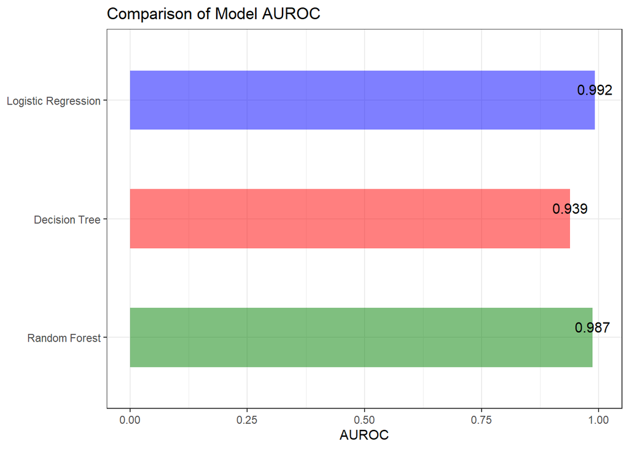

```r
# AUC를 계산합니다
auc_logit <- performance(pred_logit, "auc")@y.values[[1]]
auc_tree <- performance(pred_tree, "auc")@y.values[[1]]
auc_rf <- performance(pred_rf, "auc")@y.values[[1]]

# AUC를 데이터 프레임으로 변환합니다
auc_df <- data.frame(Model = c("Logistic Regression", "Decision Tree", "Random Forest"),
                     AUC = c(auc_logit, auc_tree, auc_rf))

# Model 변수를 팩터로 변환하고 레벨 순서를 지정합니다
auc_df$Model <- factor(auc_df$Model, levels=c("Random Forest", "Decision Tree", "Logistic Regression"))

# 색상을 벡터로 저장합니다
colors <- c("#0000FF80", "#FF000080", "#00800080")

# 바 플롯을 그립니다
ggplot(auc_df, aes(x=Model, y=AUC, fill=Model)) +
  geom_bar(stat="identity", width=0.5, fill=colors) +
  geom_text(aes(label=round(AUC, 3)), size=4, vjust=-0.5) +
  ylim(0, 1) +
  coord_flip() +
  labs(title="Comparison of Model AUROC",y="AUROC") +
  theme_bw() +
  theme(legend.position="none", axis.title.y=element_blank())
```

각 모델에 대해서 AUROC 를 구하고 시각화를 하였을때 Decison Tree < Random Forest < Logistic Regression 순으로

AUROC 의 성능이 보임

### Compare All

**Logistic Regresion, Decision Tree, Random Forest** 에 대해서 **Accuracy, AUC** 을 비교하였는데

이러한 성능 비교를 한 그래프 내에서 비교하는 과정을 진행

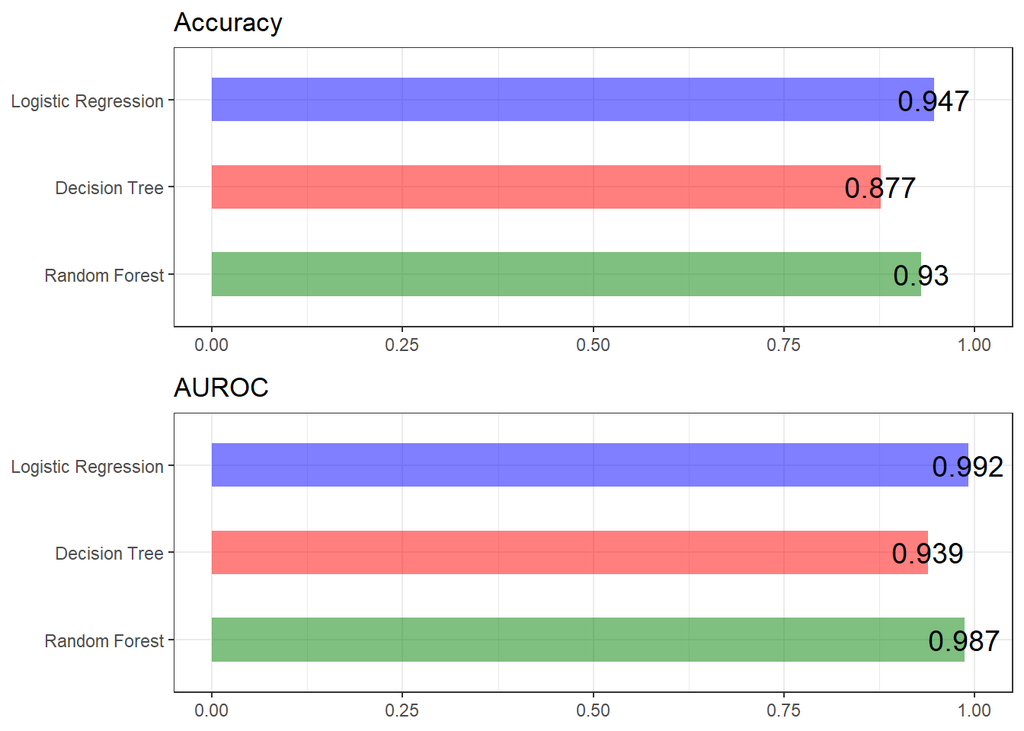

```r
# 필요한 라이브러리를 불러옵니다
library(gridExtra)

# 각각의 그래프를 생성합니다
p1 <- ggplot(acc_df, aes(x=Accuracy, y=Model, fill=Model)) +
  geom_bar(stat="identity", width=0.5, fill=colors) +
  geom_text(aes(label=round(Accuracy, 3)), size=5) +
  xlim(0, 1) +
  labs(title="Accuracy") +
  theme_bw() +
  theme(legend.position="none", axis.title.x=element_blank(), axis.title.y=element_blank())

p2 <- ggplot(auc_df, aes(x=AUC, y=Model, fill=Model)) +
  geom_bar(stat="identity", width=0.5, fill=colors) +
  geom_text(aes(label=round(AUC, 3)), size=5)  +
  xlim(0, 1) +
  labs(title="AUROC") +
  theme_bw() +
  theme(legend.position="none", axis.title.x=element_blank(), axis.title.y=element_blank())

# 3개의 그래프를 하나의 그래프로 표현합니다
grid.arrange(p1, p2, ncol=1)
```

**Logistic Regresion, Decision Tree, Random Forest** 3가지 모델에 대해서 성능 비교를 진행하였을때  
**Logistic Regresion, Random Forest** 두 모델이 상대적으로 **Decision Tree** 에 비해 좋게 나타남  
**Logistic Regresion, Random Forest** 간에는 차이가 미미하지만 **Logistic Regresion** 성능이 우수하게 나타나고 있고  
모형의 안정성과 해석적인 부분을 고려해보았을때 **Logistic Regresion** 을 이용하여 scoring 모형을 개발하는 것이 바람직하다.  
따라서 **Logistic Regresion** 모델을 이용하여 평점표 모형을 개발하도록 구상하였음

## 3. Enhance Logistic Regresion model

Logistic Regresion을 학습을 할때 cutoff value를 0.5로 지정하여 트리모델간의 동일한 조건하에 비교를 진행하였었는데 Logistic Regresion에 대해서 cutoff value값을 다양하게 하여 비교를 진행

#### Compare Cutoff value

```r
# 변수 선택 방법 설정
methods <- c("none", "forward", "backward", "both")

# 절단값 설정
cutoffs <- seq(0.4, 0.6, by = 0.05)

# 결과를 저장할 데이터 프레임 생성
results <- data.frame()

# 각 변수 선택 방법에 대해
for (method in methods) {
  # 변수 선택
  if (method == "none") {
    model <- glm(eda_formula, data=breast_cancer.train, family=binomial())
  } else {
    model <- step(glm(eda_formula, data=breast_cancer.train, family=binomial()), direction=method, trace=0)
  }

  # 각 절단값에 대해
  for (cutoff in cutoffs) {
    # 예측 생성
    pred_prob <- predict(model, newdata = breast_cancer.val, type = "response")
    pred_class <- ifelse(pred_prob > cutoff, "M", "B")

    # 정확도 계산
    acc <- mean(pred_class == breast_cancer.val$diagnosis)

    # AUROC 계산
    pred <- prediction(pred_prob, breast_cancer.val$diagnosis)
    perf <- performance(pred, measure = "auc")
    auroc <- perf@y.values[[1]]  # AUROC 값

    # '양성'과 '악성' 진단 결과에 대한 예측 확률을 분리합니다
    pred_prob_B <- pred_prob[breast_cancer.val$diagnosis == "B"]
    pred_prob_M <- pred_prob[breast_cancer.val$diagnosis == "M"]

    # AIC 계산
    aic <- model$aic

    # 결과 저장
    results <- rbind(results, data.frame(Method=method, Cutoff=cutoff, Accuracy=acc, AUROC=auroc, AIC=aic))
  }
}

# 결과 출력
print(results)
```

```
##      Method Cutoff  Accuracy     AUROC      AIC
## 1      none   0.40 0.9473684 0.9924518 140.6608
## 2      none   0.45 0.9415205 0.9924518 140.6608
## 3      none   0.50 0.9473684 0.9924518 140.6608
## 4      none   0.55 0.9415205 0.9924518 140.6608
## 5      none   0.60 0.9239766 0.9924518 140.6608
## 6   forward   0.40 0.9473684 0.9924518 140.6608
## 7   forward   0.45 0.9415205 0.9924518 140.6608
## 8   forward   0.50 0.9473684 0.9924518 140.6608
## 9   forward   0.55 0.9415205 0.9924518 140.6608
## 10  forward   0.60 0.9239766 0.9924518 140.6608
## 11 backward   0.40 0.9473684 0.9917529 133.8223
## 12 backward   0.45 0.9415205 0.9917529 133.8223
## 13 backward   0.50 0.9415205 0.9917529 133.8223
## 14 backward   0.55 0.9356725 0.9917529 133.8223
## 15 backward   0.60 0.9356725 0.9917529 133.8223
## 16     both   0.40 0.9473684 0.9917529 133.8223
## 17     both   0.45 0.9415205 0.9917529 133.8223
## 18     both   0.50 0.9415205 0.9917529 133.8223
## 19     both   0.55 0.9356725 0.9917529 133.8223
## 20     both   0.60 0.9356725 0.9917529 133.8223
```

위에서 ML 모형과의 비교를 할때 cutoff = 0.5로 지정을 하고 했었는데 출력값을 보면  
다른 cutoff 값으로 지정했을때 유의미한 값을 보이지않아서 이전과 같이 cutoff = 0.5로 유지한 상태로 다른 수치값들을 비교 진행

#### Compare AIC

```r
# 변수 선택 방법 설정
methods <- c("none", "forward", "backward", "both")

# 절단값 설정
cutoff <- 0.5

# 결과를 저장할 데이터 프레임 생성
results <- data.frame()

# 각 변수 선택 방법에 대해
for (method in methods) {
  # 변수 선택
  if (method == "none") {
    model <- glm(eda_formula, data=breast_cancer.train, family=binomial())
  } else {
    model <- step(glm(eda_formula, data=breast_cancer.train, family=binomial()), direction=method, trace=0)
  }

  # 예측 생성
  pred_prob <- predict(model, newdata = breast_cancer.val, type = "response")
  pred_class <- ifelse(pred_prob > cutoff, "M", "B")

  # 정확도 계산
  acc <- mean(pred_class == breast_cancer.val$diagnosis)

  # AUROC 계산
  pred <- prediction(pred_prob, breast_cancer.val$diagnosis)
  perf <- performance(pred, measure = "auc")
  auroc <- perf@y.values[[1]]  # AUROC 값

  # AIC 계산
  aic <- model$aic

  # 결과 저장
  results <- rbind(results, data.frame(Method=method, Cutoff=cutoff, Accuracy=acc, AUROC=auroc, AIC=aic))
}

# 결과 출력
print(results)
```

```
##     Method Cutoff  Accuracy     AUROC      AIC
## 1     none    0.5 0.9473684 0.9924518 140.6608
## 2  forward    0.5 0.9473684 0.9924518 140.6608
## 3 backward    0.5 0.9415205 0.9917529 133.8223
## 4     both    0.5 0.9415205 0.9917529 133.8223
```

Accuracy, AUROC 값은 모델간의 차이가 크게 유의미하지않아 AIc가 낮은 model 중 backward을 사용한 Logistic Regresion 모형을 이용해서 평점표 모형을 개발

## 4. Scoring model

### 평점표 작성에 사용되는 모델

Logistic Regresion model을 최종적으로 선택하였었음

```r
# Logistic Regresion model by backward
model <- step(glm(eda_formula, data=breast_cancer.train, family=binomial()), direction="backward")
```

```
## Start:  AIC=140.66
## diagnosis ~ radius_mean + texture_mean + smoothness_mean + compactness_mean +
##     symmetry_mean + fractal_dimension_mean + radius_se + texture_se +
##     smoothness_se + compactness_se + symmetry_se + fractal_dimension_se
##
##                          Df Deviance    AIC
## - smoothness_se           1   114.67 138.67
## - compactness_se          1   114.73 138.73
## - fractal_dimension_mean  1   114.86 138.85
## - symmetry_se             1   115.09 139.09
## - fractal_dimension_se    1   115.88 139.88
## - compactness_mean        1   116.03 140.03
## <none>                        114.66 140.66
## - symmetry_mean           1   117.51 141.51
## - texture_se              1   117.91 141.91
## - smoothness_mean         1   118.15 142.15
## - radius_se               1   119.62 143.62
## - radius_mean             1   137.02 161.02
## - texture_mean            1   146.86 170.86
##
## Step:  AIC=138.67
## diagnosis ~ radius_mean + texture_mean + smoothness_mean + compactness_mean +
##     symmetry_mean + fractal_dimension_mean + radius_se + texture_se +
##     compactness_se + symmetry_se + fractal_dimension_se
##
##                          Df Deviance    AIC
## - compactness_se          1   114.75 136.75
## - fractal_dimension_mean  1   114.87 136.87
## - symmetry_se             1   115.11 137.11
## - fractal_dimension_se    1   116.01 138.01
## - compactness_mean        1   116.17 138.17
## <none>                        114.67 138.67
## - symmetry_mean           1   117.66 139.66
## - texture_se              1   117.96 139.96
## - smoothness_mean         1   119.23 141.23
## - radius_se               1   119.62 141.62
## - radius_mean             1   137.02 159.02
## - texture_mean            1   147.22 169.22
##
## Step:  AIC=136.75
```

[output cut: 32 more lines]

```
##
## Step:  AIC=133.82
## diagnosis ~ radius_mean + texture_mean + smoothness_mean + compactness_mean +
##     symmetry_mean + radius_se + texture_se + fractal_dimension_se
##
##                        Df Deviance    AIC
## <none>                      115.82 133.82
## - symmetry_mean         1   118.12 134.12
## - texture_se            1   120.20 136.20
## - radius_se             1   120.39 136.38
## - fractal_dimension_se  1   121.10 137.10
## - compactness_mean      1   123.20 139.20
## - smoothness_mean       1   124.78 140.78
## - texture_mean          1   149.12 165.12
## - radius_mean           1   162.46 178.46
```

후진제거법을 통해 선정된 변수들을 보면 diagnosis ~ radius_mean + texture_mean + smoothness_mean + compactness_mean + symmetry_mean + radius_se + texture_se + fractal_dimension_se 이와 같이 radius_mean, texture_mean, smoothness_mean, compactness_mean, symmetry_mean,  
radius_se, texture_se, fractal_dimension_se 총 8개의 독립변수(설명변수)가 최종적으로 선택

### 평점표 작성에 포함되는 변수

#### 종속변수

- diagnosis: 진단 결과 (M = 악성, B = 양성)

#### 독립변수

- radius_mean: 암세포의 평균 반경
- texture_mean: 암세포의 평균 질감
- smoothness_mean: 암세포의 평균 매끄러움(종양 윤곽의 매끄러움)
- compactness_mean: 암세포의 평균 조그만함(세포의 모양이 얼마나 조밀한지)
- symmetry_mean: 암세포의 평균 대칭성
- radius_se: 암세포의 표준오차 반경
- texture_se: 암세포의 표준오차 질감
- fractal_dimension_se: 암세포의 표준오차 프랙탈 차원

```r
# model 출력
model
```

```
##
## Call:  glm(formula = diagnosis ~ radius_mean + texture_mean + smoothness_mean +
##     compactness_mean + symmetry_mean + radius_se + texture_se +
##     fractal_dimension_se, family = binomial(), data = breast_cancer.train)
##
## Coefficients:
##          (Intercept)           radius_mean          texture_mean
##             -36.5992                1.0262                0.4345
##      smoothness_mean      compactness_mean         symmetry_mean
##              79.7946               27.9530               18.3689
##            radius_se            texture_se  fractal_dimension_se
##               4.7003               -1.4729             -375.6956
##
## Degrees of Freedom: 397 Total (i.e. Null);  389 Residual
## Null Deviance:       515
## Residual Deviance: 115.8     AIC: 133.8
```

```r
# 최종 선정된 변수 목록
var_list <- c('radius_mean', 'texture_mean', 'smoothness_mean', 'compactness_mean', 'symmetry_mean', 'radius_se', 'texture_se', 'fractal_dimension_se')

# 분포 기반 범주화 및 범주 범위 출력
for (var in var_list) {
  # 범주화
  breast_cancer.train <- breast_cancer.train %>%
    mutate(!!paste0(var, "_cat") := cut(!!sym(var), breaks=quantile(!!sym(var), probs=seq(0, 1, by=0.25)), include.lowest=TRUE))

  # 범주 범위 출력
  cat(paste("Variable:", var, "\n"))
  print(summary(as.factor(breast_cancer.train[[paste0(var, "_cat")]])))
}
```

```
## Variable: radius_mean
## [6.98,11.6] (11.6,13.2] (13.2,15.4] (15.4,27.2]
##         100          99          99         100
## Variable: texture_mean
## [10.7,16.2] (16.2,18.9] (18.9,21.8] (21.8,33.6]
##         100         100          98         100
## Variable: smoothness_mean
## [0.0526,0.085] (0.085,0.0946] (0.0946,0.105]  (0.105,0.163]
##            100            101             97            100
## Variable: compactness_mean
## [0.0194,0.0631] (0.0631,0.0896]   (0.0896,0.13]    (0.13,0.287]
##             100              99              99             100
## Variable: symmetry_mean
## [0.117,0.163] (0.163,0.179] (0.179,0.195] (0.195,0.304]
##           100            99           100            99
## Variable: radius_se
## [0.112,0.232] (0.232,0.316] (0.316,0.468]  (0.468,1.51]
##           100            99            99           100
## Variable: texture_se
## [0.36,0.856] (0.856,1.14]  (1.14,1.48]  (1.48,3.65]
##          100           99           99          100
## Variable: fractal_dimension_se
## [0.000895,0.00222]  (0.00222,0.00313]   (0.00313,0.0045]    (0.0045,0.0298]
##                100                 99                 99                100
```

| Variable | 1 | 2 | 3 | 4 |
| --- | --- | --- | --- | --- |
| radius_mean | [6.98,11.6] | (11.6,13.2] | (13.2,15.4] | (15.4,27.2] |
| texture_mean | [10.7,16.2] | (16.2,18.9] | (18.9,21.8] | (21.8,33.6] |
| smoothness_mean | [0.0526,0.085] | (0.085,0.0946] | (0.0946,0.105] | (0.105,0.163] |
| compactness_mean | [0.0194,0.0631] | (0.0631,0.0896] | (0.0896,0.13] | (0.13,0.287] |
| symmetry_mean | [0.117,0.163] | (0.163,0.179] | (0.179,0.195] | (0.195,0.304] |
| radius_se | [0.112,0.232] | (0.232,0.316] | (0.316,0.468] | (0.468,1.51] |
| texture_se | [0.36,0.856] | (0.856,1.14] | (1.14,1.48] | (1.48,3.65] |
| fractal_dimension_se | [0.000895,0.00222] | (0.00222,0.00313] | (0.00313,0.0045] | (0.0045,0.0298] |

| Variable | 1 | 2 | 3 | 4 |
| --- | --- | --- | --- | --- |
| radius_mean | x < 10 | 10 <= x < 13 | 13 <= x < 16 | 16 <= x |
| texture_mean | x < 16 | 16 <= x < 19 | 19 <= x < 22 | 22 <= x |
| smoothness_mean | x < 0.08 | 0.08 <= x < 0.09 | 0.09 <= x < 0.1 | 0.10 < x |
| compactness_mean | x < 0.06 | 0.06 <= x < 0.09 | 0.09 <= x < 0.12 | 0.12 < x |
| symmetry_mean | x < 0.16 | 0.16 <= x < 0.18 | 0.18 <= x < 0.20 | 0.20 < x |
| radius_se | x < 0.22 | 0.22 <= x < 0.33 | 0.33 <= x < 0.44 | 0.44 < x |
| texture_se | x < 0.90 | 0.90 <= x < 1.20 | 1.20 <= x < 1.50 | 1.50 < x |
| fractal_dimension_se | x < 0.002 | 0.002 <= x < 0.003 | 0.003 <= x < 0.004 | 0.004 < x |

coef 값

```
     (Intercept)           radius_mean          texture_mean
        -36.5992                1.0262                0.4345
 smoothness_mean      compactness_mean         symmetry_mean
         79.7946               27.9530               18.3689
       radius_se            texture_se  fractal_dimension_se
          4.7003               -1.4729             -375.6956
```

| Variable | 1 | 2 | 3 | 4 | coef |
| --- | --- | --- | --- | --- | --- |
| radius_mean | x < 10 | 10 <= x < 13 | 13 <= x < 16 | 16 <= x | 1.0262 |
| texture_mean | x < 16 | 16 <= x < 19 | 19 <= x < 22 | 22 <= x | 0.4345 |
| smoothness_mean | x < 0.08 | 0.08 <= x < 0.09 | 0.09 <= x < 0.1 | 0.10 < x | 79.7946 |
| compactness_mean | x < 0.06 | 0.06 <= x < 0.09 | 0.09 <= x < 0.12 | 0.12 < x | 27.9530 |
| symmetry_mean | x < 0.16 | 0.16 <= x < 0.18 | 0.18 <= x < 0.20 | 0.20 < x | 18.3689 |
| radius_se | x < 0.22 | 0.22 <= x < 0.33 | 0.33 <= x < 0.44 | 0.44 < x | 4.7003 |
| texture_se | x < 0.90 | 0.90 <= x < 1.20 | 1.20 <= x < 1.50 | 1.50 < x | -1.4729 |
| fractal_dimension_se | x < 0.002 | 0.002 <= x < 0.003 | 0.003 <= x < 0.004 | 0.004 < x | -375.6956 |

## Scoring model 1

각 class(범주) 값에 coef 값을 곱해줌

| Variable | 1 | 2 | 3 | 4 | coef |
| --- | --- | --- | --- | --- | --- |
| radius_mean | 1.0262 | 2.0524 | 3.0786 | 4.1048 | 1.0262 |
| texture_mean | 0.4345 | 0.869 | 1.3035 | 1.738 | 0.4345 |
| smoothness_mean | 79.7946 | 159.5892 | 239.3838 | 319.1784 | 79.7946 |
| compactness_mean | 27.9530 | 55.906 | 83.859 | 111.812 | 27.9530 |
| symmetry_mean | 18.3689 | 36.7378 | 55.1067 | 73.4756 | 18.3689 |
| radius_se | 4.7003 | 9.4006 | 14.1009 | 18.8012 | 4.7003 |
| texture_se | -1.4729 | -2.9458 | -4.4187 | -5.8916 | -1.4729 |
| fractal_dimension_se | -375.6956 | -751.391 | -1127.09 | -1502.78 | -375.6956 |

다음으로 각 값에 2000을 더해주고 반올림하여 정수값으로 표현  
2000을 더해준 이유는 모든 값이 양의 정수로 표현함으로서 정돈된 값으로 보이기 위함

| Variable | 1 | 2 | 3 | 4 | coef |
| --- | --- | --- | --- | --- | --- |
| radius_mean | 2001 | 2002 | 2003 | 2004 | 1.0262 |
| texture_mean | 2000 | 2001 | 2001 | 2002 | 0.4345 |
| smoothness_mean | 2080 | 2160 | 2239 | 2319 | 79.7946 |
| compactness_mean | 2028 | 2056 | 2084 | 2112 | 27.9530 |
| symmetry_mean | 2018 | 2037 | 2055 | 2073 | 18.3689 |
| radius_se | 2005 | 2009 | 2014 | 2019 | 4.7003 |
| texture_se | 1999 | 1997 | 1996 | 1994 | -1.4729 |
| fractal_dimension_se | 1624 | 1249 | 873 | 497 | -375.6956 |

```r
# valdation 데이터 이용
selected_data <- breast_cancer.val %>%
  select(diagnosis, radius_mean, texture_mean, smoothness_mean, compactness_mean,
         symmetry_mean,radius_se, texture_se, fractal_dimension_se)

head(selected_data)
```

```
##    diagnosis radius_mean texture_mean smoothness_mean compactness_mean
## 1          M       17.99        10.38         0.11840          0.27760
## 2          M       20.57        17.77         0.08474          0.07864
## 9          M       13.00        21.82         0.12730          0.19320
## 15         M       13.73        22.61         0.11310          0.22930
## 17         M       14.68        20.13         0.09867          0.07200
## 18         M       16.13        20.68         0.11700          0.20220
##    symmetry_mean radius_se texture_se fractal_dimension_se
## 1         0.2419    1.0950     0.9053             0.006193
## 2         0.1812    0.5435     0.7339             0.003532
## 9         0.2350    0.3063     1.0020             0.003749
## 15        0.2069    0.2121     1.1690             0.008093
## 17        0.1586    0.4727     1.2400             0.002085
## 18        0.2164    0.5692     1.0730             0.004142
```

```r
# 각 변수에 대해 주어진 범위에 따라 클래스와 점수를 부여
score_01_data <- selected_data %>%
  mutate(radius_mean_class = ifelse(radius_mean <= 10, 1,
                                     ifelse(radius_mean <= 13, 2,
                                            ifelse(radius_mean <= 16, 3, 4))),
         radius_mean_score = ifelse(radius_mean <= 10, 2001,
                                    ifelse(radius_mean <= 13, 2002,
                                           ifelse(radius_mean <= 16, 2003, 2004))),
         texture_mean_class = ifelse(texture_mean <= 16, 1,
                                     ifelse(texture_mean <= 19, 2,
                                            ifelse(texture_mean <= 22, 3, 4))),
         texture_mean_score = ifelse(texture_mean <= 16, 2000,
                                     ifelse(texture_mean <= 19, 2001,
                                            ifelse(texture_mean <= 22, 2001, 2002))),
         smoothness_mean_class = ifelse(smoothness_mean <= 0.08, 1,
                                        ifelse(smoothness_mean <= 0.09, 2,
                                               ifelse(smoothness_mean <= 0.12, 3, 4))),
         smoothness_mean_score = ifelse(smoothness_mean <= 0.08, 2080,
                                        ifelse(smoothness_mean <= 0.09, 2160,
                                               ifelse(smoothness_mean <= 0.12, 2239, 2319))),
         compactness_mean_class = ifelse(compactness_mean <= 0.06, 1,
                                         ifelse(compactness_mean <= 0.09, 2,
                                                ifelse(compactness_mean <= 16, 3, 4))),
         compactness_mean_score = ifelse(compactness_mean <= 0.06, 2028,
                                         ifelse(compactness_mean <= 0.09, 2056,
                                                ifelse(compactness_mean <= 16, 2084, 2112))),
         symmetry_mean_class = ifelse(symmetry_mean <= 0.16, 1,
                                      ifelse(symmetry_mean <= 0.18, 2,
                                             ifelse(symmetry_mean <= 0.20, 3, 4))),
         symmetry_mean_score = ifelse(symmetry_mean <= 0.16, 2018,
                                      ifelse(symmetry_mean <= 0.18, 2037,
                                             ifelse(symmetry_mean <= 0.20, 2055, 2073))),
         radius_se_class = ifelse(radius_se <= 0.22, 1,
                                  ifelse(radius_se <= 0.33, 2,
                                         ifelse(radius_se <= 0.44, 3, 4))),
         radius_se_score = ifelse(radius_se <= 0.24, 2005,
                                  ifelse(radius_se <= 0.32, 2009,
                                         ifelse(radius_se <= 0.48, 2014, 2019))),
         texture_se_class = ifelse(texture_se <= 0.90, 1,
                                   ifelse(texture_se <= 1.20, 2,
                                          ifelse(texture_se <= 1.50, 3, 4))),
         texture_se_score = ifelse(texture_se <= 0.90, 1999,
                                   ifelse(texture_se <= 1.20, 1997,
                                          ifelse(texture_se <= 1.50, 1996, 1994))),
         fractal_dimension_se_class = ifelse(fractal_dimension_se <= 0.002, 1,
                                             ifelse(fractal_dimension_se <= 0.003, 2,
                                                    ifelse(fractal_dimension_se <= 0.004, 3, 4))),
         fractal_dimension_se_score = ifelse(fractal_dimension_se <= 0.002, 1624,
                                             ifelse(fractal_dimension_se <= 0.003, 1249,
                                                    ifelse(fractal_dimension_se <= 0.004, 873, 497))))


# _score로 끝나는 모든 변수들의 합을 계산하여 score라는 새로운 열을 생성
score_01_vars <- grep("_score$", names(score_01_data), value = TRUE)

score_01_data <- score_01_data %>% mutate(score = rowSums(.[score_01_vars]))
```

```r
group_B <- score_01_data$score[score_01_data$diagnosis == "B"]
group_M <- score_01_data$score[score_01_data$diagnosis == "M"]

# KS 통계량 계산
ks_result_01 <- ks.test(group_B, group_M)

# KS 통계량 출력
print(ks_result_01$statistic)
```

```
##         D
## 0.2324574
```

[figure not shown]

```r
# 누적 B/M 구성비 분포 그래프 그리기
ggplot() +
  stat_ecdf(data = data.frame(score = group_B, group = "B"), aes(score, colour = group)) +
  stat_ecdf(data = data.frame(score = group_M, group = "M"), aes(score, colour = group)) +
  labs(x = "Score", y = "Cumulative Proportion",
       title = "Cumulative Distribution Plot for Score",
       subtitle = "Blue: Group B, Red: Group M")
```

```r
# 'B'와 'M' 진단 그룹의 실제 라벨 생성
actual <- ifelse(score_01_data$diagnosis == "B", 0, 1)

# 예측 객체 생성
pred <- prediction(score_01_data$score, actual)

# ROC 곡선 계산
roc_obj <- performance(pred, "tpr", "fpr")

# AUROC 값 계산
auc_obj <- performance(pred, "auc")

# AUROC 값 출력
print(auc_obj@y.values[[1]])
```

```
## [1] 0.4623288
```

## Scoring model 2

| Variable | 1 | 2 | 3 | 4 | coef |
| --- | --- | --- | --- | --- | --- |
| radius_mean | x < 10 | 10 <= x < 13 | 13 <= x < 16 | 16 <= x | 1.0262 |
| texture_mean | x < 16 | 16 <= x < 19 | 19 <= x < 22 | 22 <= x | 0.4345 |
| smoothness_mean | x < 0.08 | 0.08 <= x < 0.09 | 0.09 <= x < 0.1 | 0.10 < x | 79.7946 |
| compactness_mean | x < 0.06 | 0.06 <= x < 0.09 | 0.09 <= x < 0.12 | 0.12 < x | 27.9530 |
| symmetry_mean | x < 0.16 | 0.16 <= x < 0.18 | 0.18 <= x < 0.20 | 0.20 < x | 18.3689 |
| radius_se | x < 0.22 | 0.22 <= x < 0.33 | 0.33 <= x < 0.44 | 0.44 < x | 4.7003 |
| texture_se | x < 0.90 | 0.90 <= x < 1.20 | 1.20 <= x < 1.50 | 1.50 < x | -1.4729 |
| fractal_dimension_se | x < 0.002 | 0.002 <= x < 0.003 | 0.003 <= x < 0.004 | 0.004 < x | -375.6956 |

2번째 평점표 모형을 만들때는 coef 값에 각 급간 값을 곱해주었음  
예를들어 radius_mean의 경우 급간 값이 3이므로 1.0262 * 3 의 값을 이용  
이 값에 10을 곱해주고 일의자리까지 반올림하여 표현

class(범주)가 증가할때 모든 변수 동일하게 1씩 증감  
예를들어 radius_mean의 경우 31 + 1 = 32

| Variable | 1 | 2 | 3 | 4 | coef |
| --- | --- | --- | --- | --- | --- |
| radius_mean | 31 | 32 | 33 | 34 | 1.0262 |
| texture_mean | 13 | . | . | . | 0.4345 |
| smoothness_mean | 8 | . | . | . | 79.7946 |
| compactness_mean | 4 | . | . | . | 27.9530 |
| symmetry_mean | 84 | . | . | . | 18.3689 |
| radius_se | 5 | . | . | . | 4.7003 |
| texture_se | -4 | . | . | . | -1.4729 |
| fractal_dimension_se | -4 | . | . | . | -375.6956 |

```r
# 각 변수에 대해 주어진 범위에 따라 클래스와 점수를 부여
score_02_data <- selected_data %>%
  mutate(radius_mean_score = ifelse(radius_mean <= 10, 31,
                                    ifelse(radius_mean <= 13, 32,
                                           ifelse(radius_mean <= 16, 33, 34))),

         texture_mean_score = ifelse(texture_mean <= 16, 13,
                                     ifelse(texture_mean <= 19, 14,
                                            ifelse(texture_mean <= 22, 15, 16))),

         smoothness_mean_score = ifelse(smoothness_mean <= 0.08, 8,
                                        ifelse(smoothness_mean <= 0.09, 9,
                                               ifelse(smoothness_mean <= 0.12, 10, 11))),

         compactness_mean_score = ifelse(compactness_mean <= 0.06, 4,
                                         ifelse(compactness_mean <= 0.09, 5,
                                                ifelse(compactness_mean <= 16, 6, 7))),

         symmetry_mean_score = ifelse(symmetry_mean <= 0.16, 84,
                                      ifelse(symmetry_mean <= 0.18, 85,
                                             ifelse(symmetry_mean <= 0.20, 86, 87))),

         radius_se_score = ifelse(radius_se <= 0.22, 5,
                                  ifelse(radius_se <= 0.33, 6,
                                         ifelse(radius_se <= 0.44, 7, 8))),

         texture_se_score = ifelse(texture_se <= 0.90, -4,
                                   ifelse(texture_se <= 1.20, -5,
                                          ifelse(texture_se <= 1.50, -6, -7))),

         fractal_dimension_se_score = ifelse(fractal_dimension_se <= 0.002, -4,
                                             ifelse(fractal_dimension_se <= 0.003, -5,
                                                    ifelse(fractal_dimension_se <= 0.004, -6, -7))))


# _score로 끝나는 모든 변수들의 합을 계산하여 score라는 새로운 열을 생성
score_02_vars <- grep("_score$", names(score_02_data), value = TRUE)

score_02_data <- score_02_data %>% mutate(score = rowSums(.[score_02_vars]))
```

```r
group_B <- score_02_data$score[score_02_data$diagnosis == "B"]
group_M <- score_02_data$score[score_02_data$diagnosis == "M"]

# KS 통계량 계산
ks_result_02 <- ks.test(group_B, group_M)

# KS 통계량 출력
print(ks_result_02$statistic)
```

```
##        D
## 0.826251
```

[figure not shown]

```r
# 누적 B/M 구성비 분포 그래프 그리기
ggplot() +
  stat_ecdf(data = data.frame(score = group_B, group = "B"), aes(score, colour = group)) +
  stat_ecdf(data = data.frame(score = group_M, group = "M"), aes(score, colour = group)) +
  labs(x = "Score", y = "Cumulative Proportion",
       title = "Cumulative Distribution Plot for Score",
       subtitle = "Blue: Group B, Red: Group M")
```

```r
# 'B'와 'M' 진단 그룹의 실제 라벨 생성
actual <- ifelse(score_02_data$diagnosis == "B", 0, 1)

# 예측 객체 생성
pred <- prediction(score_02_data$score, actual)

# ROC 곡선 계산
roc_obj <- performance(pred, "tpr", "fpr")

# AUROC 값 계산
auc_obj <- performance(pred, "auc")

# AUROC 값 출력
print(auc_obj@y.values[[1]])
```

```
## [1] 0.9656136
```

## Scoring model 3

3번째 평점표 모형을 만들때도 2번째 모형과 동일하개 coef 값에 각 급간 값을 곱해주었음  
이 값에 10을 곱해주고 일의자리까지 반올림하여 표현

class(범주)가 증가할때 다시한번 range의 급간 값을 이용하려 급간 값을 더해줌  
예를들어 radius_mean의 경우 급간 값이 3이므로 31 + 3 = 34

2번째 모형에서 보다 score의 분포를 퍼지게 하고 변수에 대한 가중치가 적절히 반영되도록 해주기 위함

| Variable | 1 | 2 | 3 | 4 | coef |
| --- | --- | --- | --- | --- | --- |
| radius_mean | 31 | 34 | 37 | 40 | 1.0262 |
| texture_mean | 13 | . | . | . | 0.4345 |
| smoothness_mean | 8 | . | . | . | 79.7946 |
| compactness_mean | 4 | . | . | . | 27.9530 |
| symmetry_mean | 84 | . | . | . | 18.3689 |
| radius_se | 5 | . | . | . | 4.7003 |
| texture_se | -4 | . | . | . | -1.4729 |
| fractal_dimension_se | -4 | . | . | . | -375.6956 |

```r
# 각 변수에 대해 주어진 범위에 따라 클래스와 점수를 부여
score_3_data <- selected_data %>%
  mutate(radius_mean_score = ifelse(radius_mean <= 10, 31,
                                    ifelse(radius_mean <= 13, 34,
                                           ifelse(radius_mean <= 16, 37, 40))),

         texture_mean_score = ifelse(texture_mean <= 16, 13,
                                     ifelse(texture_mean <= 19, 16,
                                            ifelse(texture_mean <= 22, 19, 22))),

         smoothness_mean_score = ifelse(smoothness_mean <= 0.08, 8,
                                        ifelse(smoothness_mean <= 0.09, 9,
                                               ifelse(smoothness_mean <= 0.12, 10, 11))),

         compactness_mean_score = ifelse(compactness_mean <= 0.06, 4,
                                         ifelse(compactness_mean <= 0.09, 6,
                                                ifelse(compactness_mean <= 16, 8, 10))),

         symmetry_mean_score = ifelse(symmetry_mean <= 0.16, 84,
                                      ifelse(symmetry_mean <= 0.18, 87,
                                             ifelse(symmetry_mean <= 0.20, 90, 93))),

         radius_se_score = ifelse(radius_se <= 0.22, 5,
                                  ifelse(radius_se <= 0.33, 6,
                                         ifelse(radius_se <= 0.44, 7, 8))),

         texture_se_score = ifelse(texture_se <= 0.90, -4,
                                   ifelse(texture_se <= 1.20, -7,
                                          ifelse(texture_se <= 1.50, -10, -13))),

         fractal_dimension_se_score = ifelse(fractal_dimension_se <= 0.002, -4,
                                             ifelse(fractal_dimension_se <= 0.003, -5,
                                                    ifelse(fractal_dimension_se <= 0.004, -6, -7))))


# _score로 끝나는 모든 변수들의 합을 계산하여 score라는 새로운 열을 생성
score_03_vars <- grep("_score$", names(score_3_data), value = TRUE)

score_3_data <- score_3_data %>% mutate(score = rowSums(.[score_03_vars]))
```

```r
group_B <- score_3_data$score[score_3_data$diagnosis == "B"]
group_M <- score_3_data$score[score_3_data$diagnosis == "M"]

# KS 통계량 계산
ks_result_03 <- ks.test(group_B, group_M)

# KS 통계량 출력
print(ks_result_03$statistic)
```

```
##        D
## 0.761532
```

[figure not shown]

```r
# 누적 B/M 구성비 분포 그래프 그리기
ggplot() +
  stat_ecdf(data = data.frame(score = group_B, group = "B"), aes(score, colour = group)) +
  stat_ecdf(data = data.frame(score = group_M, group = "M"), aes(score, colour = group)) +
  labs(x = "Score", y = "Cumulative Proportion",
       title = "Cumulative Distribution Plot for Score",
       subtitle = "Blue: Group B, Red: Group M")
```

```r
# 'B'와 'M' 진단 그룹의 실제 라벨 생성
actual <- ifelse(score_3_data$diagnosis == "B", 0, 1)

# 예측 객체 생성
pred <- prediction(score_3_data$score, actual)

# ROC 곡선 계산
roc_obj <- performance(pred, "tpr", "fpr")

# AUROC 값 계산
auc_obj <- performance(pred, "auc")

# AUROC 값 출력
print(auc_obj@y.values[[1]])
```

```
## [1] 0.9545709
```

3개의 스코어링 모델중 먼저 2, 3번째 모델의 AUROC, KS 통계량이 좋은 성능을 보이고 있고  
2번째 모델의 경우 3번째 모델보다 AUROC, KS 통계량의 값이 좋지만

K-S 통계량을 판단하는 일반적인 지침으로 “20이하 : 이용가치가 희박한”, “20~40 : 적당한”, “40~50 : 좋은”, “50~60 : 매우좋은”, “60~75 : 경이로운“,”75이상 : 지나치게 좋은(의심할 필요있는)“으로 준용하고 있다. 라고 함

이에 기반하여 평점표를 작성해보면 다음과 같다

| Variable | range | class | score |
| --- | --- | --- | --- |
| radius_mean | x < 10 | 1 | 31 |
| radius_mean | 10 <= x < 13 | 2 | 34 |
| radius_mean | 13 <= x < 16 | 3 | 37 |
| radius_mean | 16 <= x | 4 | 40 |
| texture_mean | x < 16 | 1 | 13 |
| texture_mean | 16 <= x < 19 | 2 | 16 |
| texture_mean | 19 <= x < 22 | 3 | 19 |
| texture_mean | 22 <= x | 4 | 22 |
| smoothness_mean | x < 0.08 | 1 | 8 |
| smoothness_mean | 0.08 <= x < 0.09 | 2 | 9 |
| smoothness_mean | 0.09 <= x < 0.12 | 3 | 10 |
| smoothness_mean | 0.12 < x | 4 | 11 |
| compactness_mean | x < 0.06 | 1 | 4 |
| compactness_mean | 0.06 <= x < 0.09 | 2 | 6 |
| compactness_mean | 0.09 <= x < 16 | 3 | 8 |
| compactness_mean | 16 <= x | 4 | 10 |
| symmetry_mean | x < 0.16 | 1 | 84 |
| symmetry_mean | 0.16 <= x < 0.18 | 2 | 87 |
| symmetry_mean | 0.18 <= x < 0.20 | 3 | 90 |
| symmetry_mean | 0.20 <= x | 4 | 93 |
| radius_se | x < 0.22 | 1 | 5 |
| radius_se | 0.22 <= x < 0.33 | 2 | 6 |
| radius_se | 0.33 <= x < 0.44 | 3 | 7 |
| radius_se | 0.44 <= x | 4 | 8 |
| texture_se | x < 0.90 | 1 | -4 |
| texture_se | 0.90 <= x < 1.20 | 2 | -7 |
| texture_se | 1.20 <= x < 1.50 | 3 | -10 |
| texture_se | 1.50 <= x | 4 | -13 |
| fractal_dimension_se | x < 0.002 | 1 | -4 |
| fractal_dimension_se | 0.002 <= x < 0.003 | 2 | -5 |
| fractal_dimension_se | 0.003 <= x < 0.004 | 3 | -6 |
| fractal_dimension_se | 0.004 <= x | 4 | -7 |